# 第一讲：ggplot

## 3.8 面积图

```r
head(uspopage)
```

```
##   Year AgeGroup Thousands
## 1 1900       <5      9181
## 2 1900     5-14     16966
## 3 1900    15-24     14951
## 4 1900    25-34     12161
## 5 1900    35-44      9273
## 6 1900    45-54      6437
```

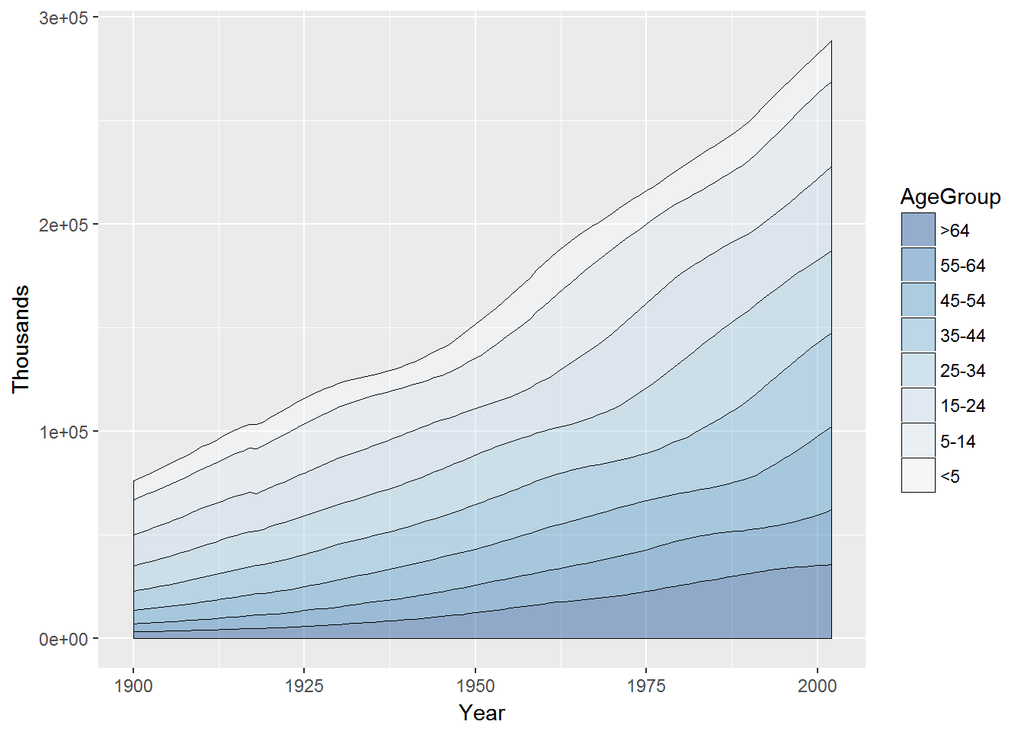

```r
ggplot(uspopage,aes(x=Year,y=Thousands,fill=AgeGroup))+geom_area(colour="black",size=.2,alpha=.4)+scale_fill_brewer(palette="Blues",breaks=rev(levels(uspopage$AgeGroup)))
```

scale_colour/fill_brewer(…, type = “seq”, palette = 1) ①type表示颜色样式 有seq、div、qual三个中选一个，即供sequential,diverging和qualitative三种种配色方案。适合用于离散数据 ②palette 表示颜色数量 数字直接表示颜色个数，也可以用相对应的名称，当表示配色方案，可以是Blues,Set1,Set2,Set3,GnBu,Reds等等 ③breaks控制着显示在坐标轴或图例上的值,rev函数进行向量倒序 关于ColorBrewer的一个介绍，可见网址：http://blog.sina.com.cn/s/blog_681aaa5501016tk4.html

geom_area() 面积图

## 3.9 综合——分组条形图（百分比）

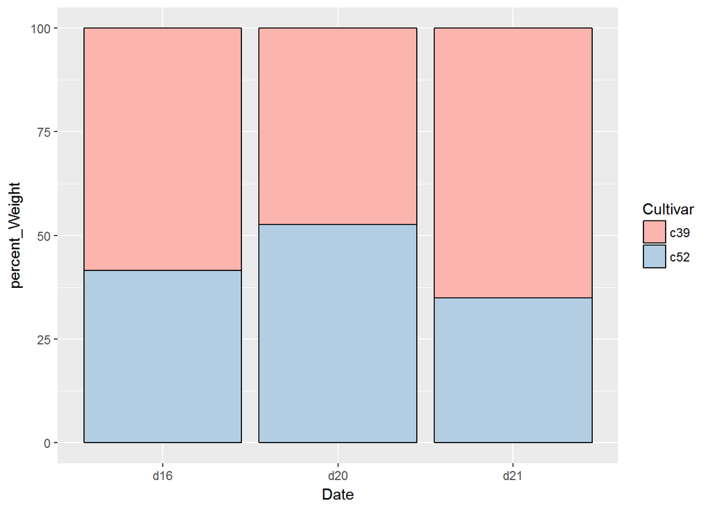

```r
library(gcookbook)
library(plyr)
ce<-ddply(cabbage_exp,"Date",transform,percent_Weight=Weight/sum(Weight)*100)
ggplot(ce,aes(x=Date,y=percent_Weight,fill=Cultivar))+geom_bar(stat="identity",colour="black")+scale_fill_brewer(palette="Pastel1")
```

#### 3.9.0.1 ddply()函数

plyr的ddply()函数能够在数据框内实现“①数据切分->②分块处理->③结果合并”三步操作，而后再根据结果生成一个新的独立数据框。这也正是ddply()函数前两个字母“dd”的含义：输入一个data frame，再得到另一个data frame。 具体格式如下： ddply(mydata, c(‘column name of a factor to group by’, ‘column name of the second factor to group by’), summarize OR transform, newcolumn = myfunction(column name(s) I want the function to act upon))

①第一个参数是原始数据框名称， ②第二个参数则是我们打算划分为子集的column名称(即以DATE为划分依据进行划分子集）。即用来分割数数据框的一个或多个*列*元素。此元素可以不是名义变量。当有多个变量时，按照各个变量的顺序依次递归对数据进行分组 ③第三个参数：transform/summarize： transform能够对不同分组内的数据进行转换。如下R语代码能够将cabbages数据框按照Cult列因子进行分组，并在数据框中创建一个新的名为DevWt的列，该新列值由原某列值减分组均值得到：

```r
library(MASS)
cb1 = ddply(cabbages, "Cult", transform, DevWt = HeadWt - mean(HeadWt))
```

```
         summarize能够对不同分组内的数据进行汇总。汇总和上面介绍的转换的区别在于汇总结果的记录数等于分组的个数，而转换操作后记录数是不变的，只是对原列进行改动转换。
         Summarize不会提供来自原始数据框中其它列中的任何信息,如果大家需要列出其它column数据，则可以把“summarize”替换为“transform”。如下R语言代码将cabbages数据框按照Cult因子进行分组，并在数据框中创建一个新的名为Devwt的列：
```

```r
cb2 = ddply(cabbages,"Cult", summarise, DevWt = HeadWt - mean(HeadWt))
head(cb1);head(cb2)
```

```
##   Cult Date HeadWt VitC      DevWt
## 1  c39  d16    2.5   51 -0.4066667
## 2  c39  d16    2.2   55 -0.7066667
## 3  c39  d16    3.1   45  0.1933333
## 4  c39  d16    4.3   42  1.3933333
## 5  c39  d16    2.5   53 -0.4066667
## 6  c39  d16    4.3   50  1.3933333
```

```
##   Cult      DevWt
## 1  c39 -0.4066667
## 2  c39 -0.7066667
## 3  c39  0.1933333
## 4  c39  1.3933333
## 5  c39 -0.4066667
## 6  c39  1.3933333
```

④第四项参数用于命名新column并列出我们希望ddply()使用的函数清单(即写函数)。

> 引用 豆瓣上一个很好的关于分组的R语言教程：https://www.douban.com/group/topic/64853383/

## 3.10 气泡图

```r
head(countries)
```

```
##          Name Code Year      GDP laborrate healthexp infmortality
## 1 Afghanistan  AFG 1960 55.60700        NA        NA           NA
## 2 Afghanistan  AFG 1961 55.66865        NA        NA           NA
## 3 Afghanistan  AFG 1962 54.35964        NA        NA           NA
## 4 Afghanistan  AFG 1963 73.19877        NA        NA           NA
## 5 Afghanistan  AFG 1964 76.37303        NA        NA           NA
## 6 Afghanistan  AFG 1965 94.09873        NA        NA           NA
```

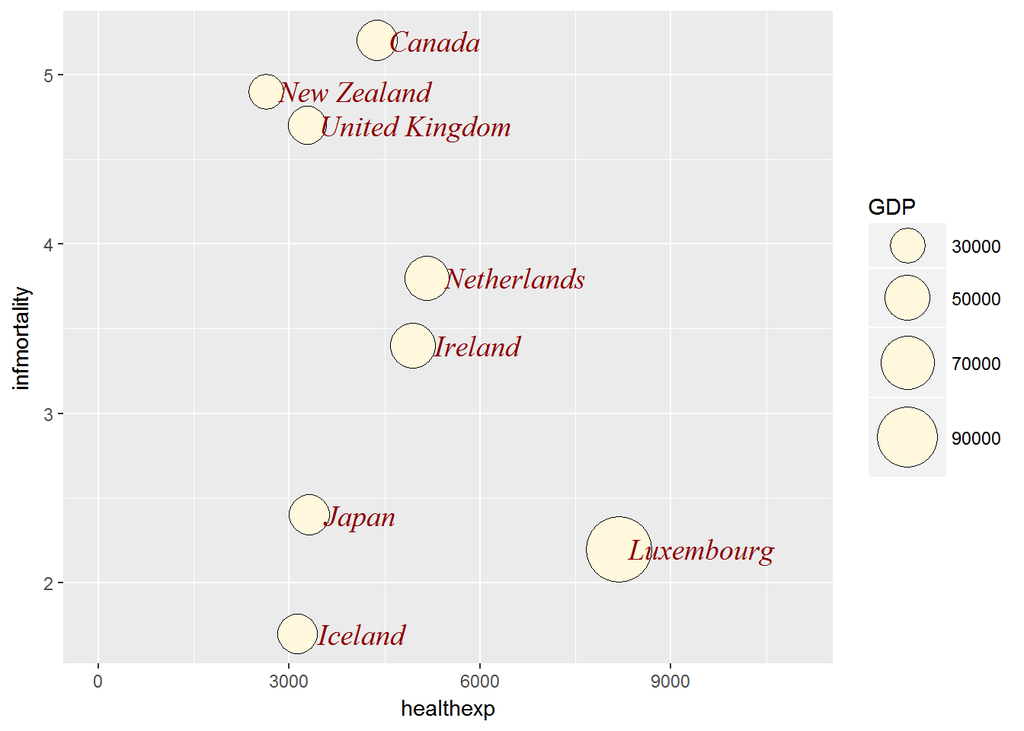

```r
cdat=subset(countries,Year==2009&Name %in% c("Canada","Ireland","United Kingdom","New Zealand","Iceland","Japan","Luxembourg","Netherlands","Switherland"))
g=ggplot(cdat,aes(x=healthexp,y=infmortality,size=GDP))+geom_point(shape=21,colour="black",fill="cornsilk")+scale_size_area(max_size=15)
n=nrow(cdat)
for(i in 1:n){
  g=g+annotate("text",x=cdat[i,]$healthexp+100*nchar(as.character(cdat$Name[i]))+300,y=cdat[i,]$infmortality,label=cdat[i,]$Name,family="serif",fontface="italic",colour="darkred",size=5)
}
g+scale_x_continuous(limits = c(0,11000))
```

%in% 取子集

在给本图添加label的时候，使用循环语句。 坐标需要根据国家名字的长度进行向右移动的调整，不同国家由于名字不一样长，向右移动的距离不一样。且要改变x坐标轴的长度，以方便完全显示出label。

scale_x_continuous(limits = c(0,11000)) 设置了x轴范围